# Линейная регрессия

**Суммарное количество баллов: 10**

**Решение отправлять на `ml.course.practice@gmail.com`**

**Тема письма: `[ML][HW010] <ФИ>`, где вместо `<ФИ>` указаны фамилия и имя**

```python
from sklearn.datasets import make_blobs, make_moons
from sklearn.model_selection import train_test_split
import numpy as np
import random
import matplotlib.pyplot as plt
import matplotlib
import copy
import scipy.linalg
```

```python
def read_data(path="../data/boston.csv"):
    dataframe = np.genfromtxt(path, delimiter=",", skip_header=15)
    X = dataframe[:, :-1]
    y = dataframe[:, -1]
    maxs = np.max(X, axis=0)
    mins = np.min(X, axis=0)
    X = (X - mins) / maxs
    X = 2 * X - 1
    return X, y
```

```python
def generate_synthetic(size, dim=6, noise=0.1):
    X = np.random.randn(size, dim)
    w = np.random.randn(dim + 1)
    noise = noise * np.random.randn(size)
    y = X.dot(w[1:]) + w[0] + noise
    return X, y
```

### Задание 1 (1 балл)

Для начала нужно понять, какую метрику для ошибки будем использовать. В нашем случае нам подойдет стандартная метрика MSE. Ее и нужно реализовать.

```python
def mse(y_true, y_predicted):
    return np.mean((y_true - y_predicted)**2)
```

### Задание 2 (3 балла)

Теперь реализуем линейную регрессию при помощи явного решения задачи минимизации.

#### Методы

`fit(X, y)` - решает задачу минимизации $\arg\min_{w, b}\sum ((w\cdot x + b) - y)^2$.

`predict(X)` - строит предсказание `y` для объектов из `X`.

```python
class NormalLR:
    def __init__(self):
        pass

    def fit(self, X, y):
        X = np.hstack((X, np.ones(shape=(X.shape[0], 1))))
        Xty = X.T.dot(y)
        XtX = X.T.dot(X)
        self.w = scipy.linalg.solve(XtX, Xty)

    def predict(self, X):
        return X.dot(self.w[:-1]) + self.w[-1]
```

```python
X, y = generate_synthetic(1024)
# X, y = read_data()
X_train, X_test, y_train, y_test = train_test_split(X, y, train_size=0.8)
```

```python
regr = NormalLR()
regr.fit(X_train, y_train)
print(mse(y_test, regr.predict(X_test)))
```

```
0.00955147922024008
```

### Задание 3 (2 балла)

Теперь реализуем линейную регрессию с использованием градиентного спуска с larning rate `alpha` в течении `iterations` итераций.

#### Методы

`fit(X, y)` - приближает решение задачи минимизации $\arg\min_{w, b}\sum ((w\cdot x + b) - y)^2$ при помощи градиентного спуска.

`predict(X)` - строит предсказание `y` для объектов из `X`.

### Задание 4 (2 балла)

Добавьте в метод `fit` регуляризацию Лассо с коэффициентом `l`. Постройте график зависимости ошибки предсказания данных из синтетического набора данных от коэффициента регуляризации

```python
class GradientLR:
    def __init__(self, alpha, iterations=10000, l=0.):
        self.iterations = iterations
        self.alpha = alpha
        self.l = l

    def fit(self, X, y):
        X = np.hstack((X, np.ones(shape=(X.shape[0], 1))))

        def grad(teta):
            return (2 * X.T.dot(X.dot(teta)) -
                    2 * X.T.dot(y)) / X.shape[0] + self.l * np.sign(teta)

        self.w = np.random.randn((X.shape[1]))
#         self.w = np.zeros(X.shape[1])
        for _ in range(self.iterations):
            self.w -= self.alpha * grad(self.w)

    def predict(self, X):
        return X.dot(self.w[:-1]) + self.w[-1]
```

```python
def build_plot(X_train, y_train, X_test, y_test, alpha=0.01, beg=-5, end=-2):
    ls = np.arange(beg, end, (end - beg) / 100)
    ys = []
    for l in ls:
        gradLR = GradientLR(alpha, iterations=1000, l=np.power(10, l))
        gradLR.fit(X_train, y_train)
        ys.append(mse(gradLR.predict(X_test), y_test))
    plt.plot(ls, ys)
    plt.xlabel('log10(l)')
```

```python
X, y = generate_synthetic(1024)
X_train, X_test, y_train, y_test = train_test_split(X, y, train_size=0.8)
```

```
0.008179187839417679
```

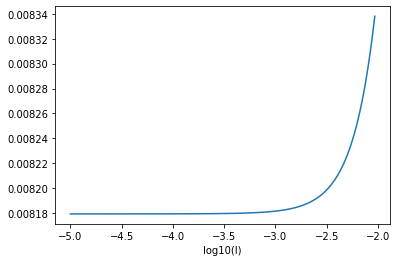

```python
regr = GradientLR(0.01, iterations=10000)
regr.fit(X_train, y_train)
print(mse(y_test, regr.predict(X_test)))
build_plot(X_train, y_train, X_test, y_test)
```

```python
X, y = generate_synthetic(1024)
X_train, X_test, y_train, y_test = train_test_split(X, y, train_size=0.8)
```

```
0.009660587894561333
```

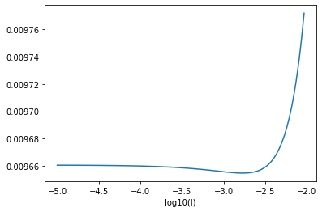

```python
regr = GradientLR(0.01, iterations=10000)
regr.fit(X_train, y_train)
print(mse(y_test, regr.predict(X_test)))
build_plot(X_train, y_train, X_test, y_test)
```

```python
X, y = generate_synthetic(1024)
X_train, X_test, y_train, y_test = train_test_split(X, y, train_size=0.8)
```

```
0.010186953373188782
```

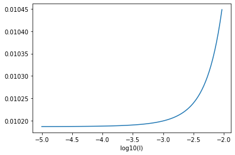

```python
regr = GradientLR(0.01, iterations=10000)
regr.fit(X_train, y_train)
print(mse(y_test, regr.predict(X_test)))
build_plot(X_train, y_train, X_test, y_test)
```

Результаты сильно зависят от сгерерированного датасета. Часто оптимальным оказывается нулевой коэффицент, а иногда лучшие результаты показывает коэффицент порядка 1e-3.

### Задание 5 (2 балла)

Протесируйте оба метода на данных `boston.csv`, для градиентного спуска постройте график зависимости ошибки от коэффициента регуляризации.

```python
X, y = read_data()
X_train, X_test, y_train, y_test = train_test_split(X, y, train_size=0.8, shuffle=False)
```

```python
regr = NormalLR()
regr.fit(X_train, y_train)
print(mse(y_test, regr.predict(X_test)))
print(mse(y_test, 0))
```

```
32799862.680209603
283704705.88235295
```

```
27755107.289856307
283704705.88235295
```

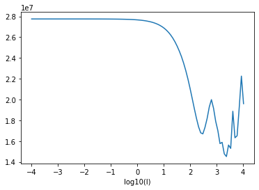

```python
regr = GradientLR(0.1, iterations=1000)
regr.fit(X_train, y_train)
print(mse(y_test, regr.predict(X_test)))
print(mse(y_test, 0))
build_plot(X_train, y_train, X_test, y_test, alpha=0.1, beg=-4, end=4.1)
```

Интересно, что градиентный спуск показывает лучшие результаты, чем точное решение оптимизационной задачи. Вероятно происходит переобучение, потому что при большем количестве итераций результат снова ухудшается. Также результат очень сильно зависит от альфы, при маленьких значениях нужно больше итераций чтобы сойтись достаточно хорошо.

```python
regr = GradientLR(0.1, iterations=1000, l=np.power(10, 3.25))
regr.fit(X_train, y_train)
print(mse(y_test, regr.predict(X_test)))
```

```
14754010.534363383
```

Путь при спуске пропорционален примерно iterations * alpha:

```python
regr = GradientLR(0.1, iterations=10, l=np.power(10, 3.25))
regr.fit(X_train, y_train)
print(mse(y_test, regr.predict(X_test)))
regr = GradientLR(0.01, iterations=100, l=np.power(10, 3.25))
regr.fit(X_train, y_train)
print(mse(y_test, regr.predict(X_test)))
regr = GradientLR(0.001, iterations=1000, l=np.power(10, 3.25))
regr.fit(X_train, y_train)
print(mse(y_test, regr.predict(X_test)))
```

```
23084701.160606805
22587452.311673574
22502657.541232567
```

```python
regr = GradientLR(0.1, iterations=100, l=np.power(10, 3.25))
regr.fit(X_train, y_train)
print(mse(y_test, regr.predict(X_test)))
regr = GradientLR(0.01, iterations=1000, l=np.power(10, 3.25))
regr.fit(X_train, y_train)
print(mse(y_test, regr.predict(X_test)))
regr = GradientLR(0.001, iterations=10000, l=np.power(10, 3.25))
regr.fit(X_train, y_train)
print(mse(y_test, regr.predict(X_test)))
```

```
19796099.385430135
19562109.279830538
19572540.464454282
```

```python
regr = GradientLR(0.1, iterations=1000, l=np.power(10, 3.25))
regr.fit(X_train, y_train)
print(mse(y_test, regr.predict(X_test)))
regr = GradientLR(0.01, iterations=10000, l=np.power(10, 3.25))
regr.fit(X_train, y_train)
print(mse(y_test, regr.predict(X_test)))
regr = GradientLR(0.001, iterations=100000, l=np.power(10, 3.25))
regr.fit(X_train, y_train)
print(mse(y_test, regr.predict(X_test)))
```

```
14754010.534363383
15123452.379505496
15162722.39696977
```

```python
regr = GradientLR(0.1, iterations=10000, l=np.power(10, 3.25))
regr.fit(X_train, y_train)
print(mse(y_test, regr.predict(X_test)))
regr = GradientLR(0.01, iterations=100000, l=np.power(10, 3.25))
regr.fit(X_train, y_train)
print(mse(y_test, regr.predict(X_test)))
regr = GradientLR(0.001, iterations=1000000, l=np.power(10, 3.25))
regr.fit(X_train, y_train)
print(mse(y_test, regr.predict(X_test)))
```

```
16493697.5074366
16004562.920087304
16007083.43384609
```